# 7th plate design

RT optimisation with the Labcyte Echo 525: dNTPs and divalent ions.

# Influence of dNTP concentration and divalent ions

It has been reported ([Lee et al., 2017](https://pubmed.gov/28327113)) that increasing [dNTP] (dNTP concentration) increases tailing and favors template switching. Here, we the goal is to replicate and extend the results, and check if [dNTP] has a positive or negative impact on cap specificity.

Increase of magnesium concentrations has been reported to enhance yield, and addition of manganese was reported to enhance template switching. Moreover, increase of [dNTP] must be compensated by increase of divalent ions (magnesium or manganese), otherwise too many of them will be be chelated and the reaction will be inhibited. Indeed, [dNTP] is never higher than [Mg<sup>2+</sup>] + [Mn<sup>2+</sup>] in transcriptome protocols. Therefore various combinations of dNTP and divalent ion concentrations will be tested.

In this design, the TSOs and ion concentrations are randomised as much as possible (taking into account that all do not have the same stock concentrations). A fixed TSO, RT primer and RNA concentration is chosen, based on the results of Experiment 7.

For each plate replicate, a different random seed is used, to generate different randomisations.

Compared with the previous design, all replicate randomisations and transfers are calculated at once, to prevent from running out of reagents.

### Post-experimental notes

# Load R packages and scripts

```r
library("magrittr")   # For its diamond pipe operators
library("ggplot2")    # For plotting
library("platetools") # For defining and manipulating 384-well plates
library("plyr")
library("tibble")     # For comfortable command-line operations

# The set_block function that will become part of platetools
source("https://raw.githubusercontent.com/charles-plessy/platetools/76213accb1704d11a2d96fb1f6284d0b46117778/R/set_block.R")

# Do not load the whole smallCAGEqc package, just get the barcode data.
data("nanoCAGE2017barcodes", package = "smallCAGEqc")
```

# Selected TSOs

TSOs are selected according to remaining volume. See the file Labcyte-RT7_TSO_stock_to_source.xls for details on the cherry-picking of the TSOs. This time, the concentrations are adjusted according to the concentration check of the stock plate PO_8268526.

```r
#           1   2   3   4   5   6   7
TSOs <- c(  1, 13, 25, 37, 49, 61, 73  # A
         ,  2, 14, 39, 38, 50, 62, 74  # B
         ,  4, 16, 28, 40, 64, 76, 88  # C
         ,  5, 17, 29, 41, 65, 77, 89  # D
         , 51, 18, 30, 42, 66, 78, 90  # E
         ,  7, 19, 31, 43, 67, 79, 91  # F
         ,  8, 87, 32, 44, 68, 80, 92  # G
         ,  9, 21, 33, 45, 69, 81, 24  # H
         , 71, 23, 60, 47, 70, 83, 36  # I
         , 72, 22, 35, 46, 59, 82, 48) # J
```

# Combinations of magnesium and dNTP concentrations

This goes to high extremes, but Smart-Seq 2 has 1 mM dNTP and 12 mM MgCl<sub>2</sub>…

Master Mix “SSIII” uses the standard SSIII first-strand buffer (375 mM KCl, 15 mM MgCl<sub>2</sub>, 250 mM Tris-HCl pH 8.3), and Master Mix “Custom” is the same, without MgCl<sub>2</sub>.

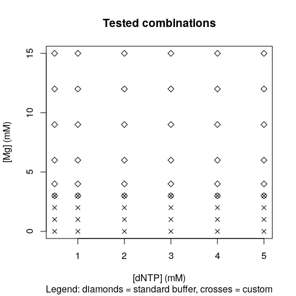

```r
combi <- expand.grid( dNTP = c(0.5, 1:5)
                    , Mg   = c(0:3, 3, 4, 6, 9, 12, 15))
combi$MMix <- c(rep("Custom", 24), rep("SSIII", 36))

plot(combi$dNTP, combi$Mg, xlab = "[dNTP] (mM)", ylab ="[Mg] (mM)", main = "Tested combinations", pch = combi$MMix %>% factor %>% as.numeric + 3
     , sub = "Legend: diamonds = standard buffer, crosses = custom")
```

Conveniently, there are 60 remaining combinations, which leaves space for 4 negative control.

# Creation of sextants

```r
createRandomisedSextant <- function(index, Mn) {
  df                       <- data.frame(BARCODE_ID = sample(TSOs, 64))
  df$TSO_source            <- 200
  df$TSO_vol               <- 25
  df$TSO                   <- df$TSO_source * df$TSO_vol / 500
  df$RT_PRIMERS            <- 1
  df$RNA                   <- 10
  df$RT_PRIMERS_RNA_vol    <- 25
  df$MMix                  <- c(combi$MMix, c("Custom", "Custom", "SSIII", "SSIII"))
  df$MASTER_MIX_vol        <- 300
  df$INDEX                 <- index
  df$Mn                    <- Mn
  df$Mn_vol                <- 25
  df[df$Mn == 0, "Mn_vol"] <- 0
  df$Mg                    <- c(combi$Mg, 3, 3, 0, 0)
  df$Mg_vol                <- 25
  df[df$Mg == 0, "Mg_vol"] <- 0
  df$dNTP                  <- c(combi$dNTP, 0, 0, 0, 0)
  df$dNTP_vol              <- 100
  df[61:64, "dNTP_vol"]    <- 0  # Negative controls

  df$H2O_vol <- 500 - with(df, dNTP_vol + Mn_vol + Mg_vol +
                               TSO_vol + RT_PRIMERS_RNA_vol +
                               MASTER_MIX_vol)
  df[sample(nrow(df)),]
}
```

# Create plates

```r
mkPlate <- function(randomSeed, plateID, indexes) {
  plate           <- tibble(well = platetools::num_to_well(1:384, plate = "384"))
  plate$row       <- sub("..$", "", plate$well) %>% factor
  plate$col       <- sub("^.",  "", plate$well) %>% as.numeric %>% factor

  set.seed(randomSeed)
  plate$sxt <- paste0 (
    c(rep("A", 8), rep("B", 8), rep("C", 8)),
    ifelse (plate$row %in% LETTERS[1:8 * 2], 2, 1)
  ) %>% factor

  plate %<>% arrange(sxt)

  plate %<>% cbind( rbind( createRandomisedSextant(indexes[1], 0)
                         , createRandomisedSextant(indexes[2], 1)
                         , createRandomisedSextant(indexes[3], 2)
                         , createRandomisedSextant(indexes[4], 3)
                         , createRandomisedSextant(indexes[5], 4)
                         , createRandomisedSextant(indexes[6], 5))
        ) %>% as.tibble()

  plate$INDEX %<>% factor
  plate$BARCODE_SEQ <- nanoCAGE2017barcodes[plate$BARCODE_ID, "barcodes"]

  plate$Mg_level     <- plate$Mg   %>% factor(labels = paste0("Mg_",   LETTERS[1:9]))
  plate$Mn_level     <- plate$Mn   %>% factor(labels = paste0("Mn_",   LETTERS[1:6]))
  plate$dNTP_level   <- plate$dNTP %>% factor(labels = paste0("dNTP_", LETTERS[1:7]))
  plate$plateID <- plateID
  plate
}

plate7a <- mkPlate(1, "U", c("TAAGGCGA", "CGTACTAG", "AGGCAGAA", "TCCTGAGC", "GGACTCCT", "TAGGCATG"))
plate7b <- mkPlate(2, "V", c("CTCTCTAC", "CGAGGCTG", "AAGAGGCA", "GTAGAGGA", "GCTCATGA", "ATCTCAGG"))
plate7c <- mkPlate(3, "W", c("ACTCGCTA", "GGAGCTAC", "GCGTAGTA", "CGGAGCCT", "TACGCTGC", "ATGCGCAG"))
plate7d <- mkPlate(4, "X", c("TAGCGCTC", "ACTGAGCG", "CCTAAGAC", "CGATCAGT", "TGCAGCTA", "TCGACGTC"))
```

### Summary

```r
writePlate <- function(plate) {
  plateName <- deparse(substitute(plate))
  write.table( plate
             , paste0(plateName, ".txt")
             , sep = "\t"
             , quote = FALSE
             , row.names = FALSE)
}

writePlate(plate7a)
writePlate(plate7b)
writePlate(plate7c)
writePlate(plate7d)
```

# Plate maps for randomisation a

```r
plateMap <- function(x, title) {
  plate <- plate7a
  platetools::raw_map(plate[[x]], well=plate$well, plate="384") +
  ggtitle(title) +
  viridis::scale_fill_viridis(breaks = unique(plate[[x]]))
}

plateMapLog <- function(x, title) {
  plate <- plate7a
  platetools::raw_map(plate[[x]], well=plate$well, plate="384") +
  ggtitle(title) +
  viridis::scale_fill_viridis(breaks = unique(plate[[x]]), trans = "log")
}
```

## dNTP, Mg, Mn

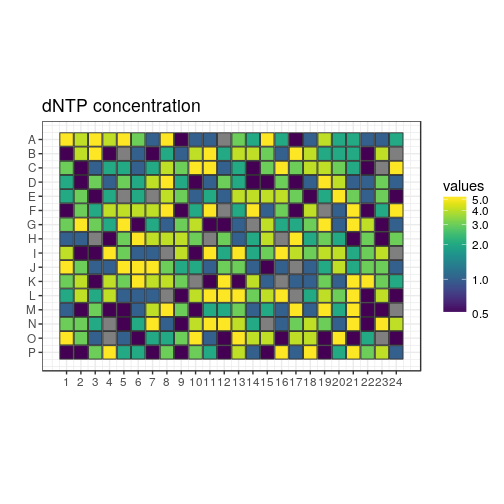

```r
(plot_dNTP <- plateMapLog("dNTP", "dNTP concentration"))
```

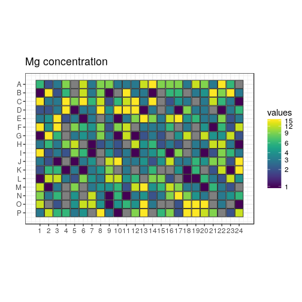

```r
(plot_Mg   <- plateMapLog("Mg",   "Mg concentration"))
```

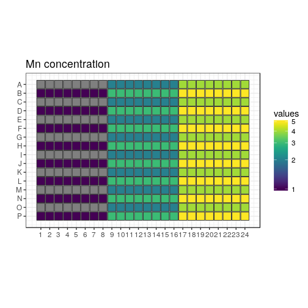

```r
(plot_Mn   <- plateMapLog("Mn",   "Mn concentration"))
```

## Barcode IDs

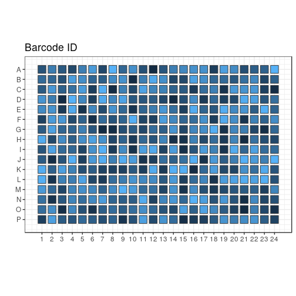

```r
(plot_BARCODES <- platetools::raw_map(plate7a[["BARCODE_ID"]], well=plate7a$well, plate="384") +
  ggtitle("Barcode ID")) + theme(legend.position="none")
```

## Indexes

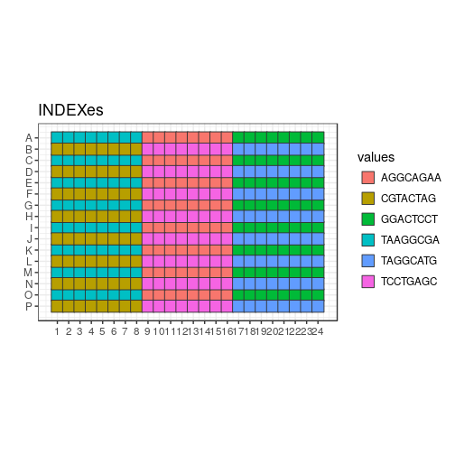

```r
(plot_indexes <- platetools::raw_map(plate7a[["INDEX"]], well=plate7a$well, plate="384") +
  ggtitle("INDEXes"))
```

## H2O

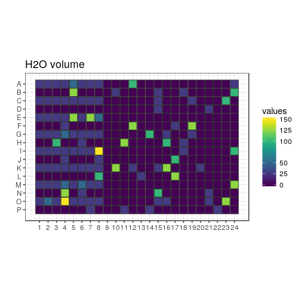

```r
(plot_H2O_vol <- plateMap("H2O_vol", "H2O volume"))
```

# Transfer file

## Source plate layout

### TSOs in wells A01~J07

Source plate concentration is 200 μM, for a 10 μM final concentration (25 nL transfer). This time, the dilution factors calculated from the concentration checks in the stock plate have been applied. The TSOs will be in wells A1 to J7 of the source plate. Actual concentrations will be checked in TSO_concentration_check5.

```r
tso_block <- data.frame( id  = TSOs
                       , row = unlist(lapply(LETTERS[1:10], rep, 7))
                       , col = rep(1:7, 10))

tso_block$well <- paste0(tso_block$row, "0", tso_block$col)

tso_block$barcodes <- nanoCAGE2017barcodes[tso_block$id, "barcodes"]

source <- tibble(well = platetools::num_to_well(1:384, plate = "384"))

for (n in 1:nrow(tso_block))
  source %<>% set_block( tso_block[n,"well"]
                       , tso_block[n,"barcodes"]
                       , 20000)
```

### RNA / RT primer mix in well K01

This time it was needed to combine RNA and RT primers to reduce the total volume. Fixed RT primer concentration and RNA amount: 20 μM RT primer ; 400 ng / μL RNA.

```r
source %<>% set_block("K01", "RT_PRIMERS_RNA", 60000)
```

### Water in well K02

```r
source %<>% set_block("K02", "H2O", 60000)
```

### Mn<sup>2+</sup> in wells L01 to L05

Wells L01 to L05 filled with 20, 40, 60, 80 and 100 μM MnCl<sub>2</sub> respectively.

```r
levels(plate7a$Mn %>% factor)
```

```
## [1] "0" "1" "2" "3" "4" "5"
```

```r
levels(plate7a$Mn_level)
```

```
## [1] "Mn_A" "Mn_B" "Mn_C" "Mn_D" "Mn_E" "Mn_F"
```

```r
source %<>% set_block("L01", "Mn_B", 60000)
source %<>% set_block("L02", "Mn_C", 60000)
source %<>% set_block("L03", "Mn_D", 60000)
source %<>% set_block("L04", "Mn_E", 60000)
source %<>% set_block("L05", "Mn_F", 60000)
```

### Mg<sup>2+</sup> in wells M01 to M08

Wells M01 to M08 filled with 20, 40, 60, 80, 120, 180, 240, and 300 μM MgCl<sub>2</sub> respectively.

```r
levels(plate7a$Mg %>% factor)
```

```
## [1] "0"  "1"  "2"  "3"  "4"  "6"  "9"  "12" "15"
```

```r
levels(plate7a$Mg_level)
```

```
## [1] "Mg_A" "Mg_B" "Mg_C" "Mg_D" "Mg_E" "Mg_F" "Mg_G" "Mg_H" "Mg_I"
```

```r
source %<>% set_block("M01", "Mg_B", 60000)
source %<>% set_block("M02", "Mg_C", 60000)
source %<>% set_block("M03", "Mg_D", 60000)
source %<>% set_block("M04", "Mg_E", 60000)
source %<>% set_block("M05", "Mg_F", 60000)
source %<>% set_block("M06", "Mg_G", 60000)
source %<>% set_block("M07", "Mg_H", 60000)
source %<>% set_block("M08", "Mg_I", 60000)
```

### dNTPs

Wells N01 to N06 filled with 2.5, 5, 10, 15, 20, 25 mM dNTPs respectively.

```r
levels(plate7a$dNTP %>% factor)
```

```
## [1] "0"   "0.5" "1"   "2"   "3"   "4"   "5"
```

```r
levels(plate7a$dNTP_level)
```

```
## [1] "dNTP_A" "dNTP_B" "dNTP_C" "dNTP_D" "dNTP_E" "dNTP_F" "dNTP_G"
```

```r
source %<>% set_block("N01", "dNTP_B", 60000)
source %<>% set_block("N02", "dNTP_C", 60000)
source %<>% set_block("N03", "dNTP_D", 60000)
source %<>% set_block("N04", "dNTP_E", 60000)
source %<>% set_block("N05", "dNTP_F", 60000)
source %<>% set_block("N06", "dNTP_G", 60000)
```

### Mastermixes

Wells O01 to O06 filled with custom mastermix; wells P01 to P07 filled with standard mastermix.

For reducing the volume (to give more flexibility to the transfers), DTT concentration was reduced from 10 to 7 mM. Let’s hope it has no impact.

```r
levels(plate7a$MMix %>% factor)
```

```
## [1] "Custom" "SSIII"
```

```r
source %<>% set_block("O01~O06", "Custom", 60000)
source %<>% set_block("P01~P07", "SSIII",  60000)
```

## Plan plate

```r
mkPlanPlate <- function(plate) {
  planPlate <- tibble(well = platetools::num_to_well(1:384, plate = "384"))

  for (n in 1:nrow(plate)) {
    planPlate %<>% set_block( plate[[n,"well"]]
                            , plate[[n,"BARCODE_SEQ"]] %>% as.character
                            , plate[[n,"TSO_vol"]])

    planPlate %<>% set_block( plate[[n,"well"]]
                            , "H2O"
                            , plate[[n,"H2O_vol"]])

    planPlate %<>% set_block( plate[[n,"well"]]
                            , "RT_PRIMERS_RNA"
                            , plate[[n,"RT_PRIMERS_RNA_vol"]])

    planPlate %<>% set_block( plate[[n,"well"]]
                            , plate[[n,"Mg_level"]] %>% as.character
                            , plate[[n,"Mg_vol"]])

    planPlate %<>% set_block( plate[[n,"well"]]
                            , plate[[n,"Mn_level"]] %>% as.character
                            , plate[[n,"Mn_vol"]])

    planPlate %<>% set_block( plate[[n,"well"]]
                            , plate[[n,"dNTP_level"]] %>% as.character
                            , plate[[n,"dNTP_vol"]])

    planPlate %<>% set_block( plate[[n,"well"]]
                            , plate[[n,"MMix"]] %>% as.character
                            , plate[[n,"MASTER_MIX_vol"]])
  }
  planPlate %<>% replace( . == 0, NA)
  planPlate <- planPlate[,sapply(planPlate, function(x) !all(is.na(x)))]
  planPlate
}
```

## Plan transfer

```r
source("plates.R")
source("echo.R")

planPlate7a <- Plate(plate = mkPlanPlate(plate7a))
sourcePlate <- Plate(plate = source, deadVolume = 16000)
destPlate   <- Plate(plate = tibble::tibble(well = num_to_well(1:384, plate = "384")))

echo <- planTransfers(sourcePlate, destPlate, planPlate7a)
echo
```

```
## A 525 Echo machine:
##   Source plate:      A Plate with data about 384 wells (dead volume: 16000; max volume: 1e+05).
##   Destination plate: A Plate with data about 384 wells (dead volume: 10000; max volume: 1e+05).
## Transducer at the following coordinates:
##   Source:      L05 (384-well format)
##   Destination: P24 (384-well format)
## 2282 elements in the log.
```

```r
echo@source@plate[,-1] %>% colSums(na.rm = TRUE)
```

```
##         ACACAG         AGTCAG         ATCTAC         CGACAG         CTGCAG         GAGTAC
##          19875          19875          19850          19875          19850          19875
##         GTACAG         ACACGT         AGTCGT         CGACTC         CGACGT         CTGCGT
##          19875          19875          19875          19850          19850          19875
##         GAGTCT         GTACGT         ACAGAT         AGTGAT         CACACG         CGAGAT
##          19850          19850          19875          19850          19850          19850
##         GCTACG         GTAGAT         TATGAT         ACAGCA         AGTGCA         CACAGC
##          19850          19850          19875          19875          19875          19875
##         CGAGCA         GCTAGC         GTAGCA         TATGCA         CTGCTC         AGTGTG
##          19900          19850          19875          19850          19875          19850
##         CACATA         CGAGTG         GCTATA         GTAGTG         TATGTG         ACATAC
##          19950          19875          19850          19875          19850          19875
##         ATCACG         CACGAT         CGATAC         GCTCAG         GTATAC         TCGACG
##          19850          19900          19875          19875          19850          19850
##         ACATCT         TATCTC         CACGCA         CGATCT         GCTCGT         GTATCT
##          19850          19850          19850          19875          19850          19925
##         TCGAGC         ACATGA         ATCATA         CACGTG         CGATGA         GCTCTC
##          19850          19875          19875          19850          19850          19875
##         GTATGA         ATCGTG         GCTGCA         ATCGCA         GAGCTC         CTGAGC
##          19850          19850          19850          19850          19850          19850
##         GCTGAT         TATAGC         CACTGA         GCTGTG         ATCGAT         CACTCT
##          19875          19850          19850          19850          19850          19850
##         CTGACG         GAGCGT         TATACG         CTGATA RT_PRIMERS_RNA            H2O
##          19850          19850          19850          19850          50400          54800
##           Mn_B           Mn_C           Mn_D           Mn_E           Mn_F           Mg_B
##          58400          58400          58400          58400          58400          59100
##           Mg_C           Mg_D           Mg_E           Mg_F           Mg_G           Mg_H
##          59100          57900          59100          59100          59100          59100
##           Mg_I         dNTP_B         dNTP_C         dNTP_D         dNTP_E         dNTP_F
##          59100          54000          54000          54000          54000          54000
##         dNTP_G         Custom          SSIII
##          54000         313200         351600
```

```r
transfers7a <- as.data.frame(echo %>% showLogs)
transfers7a <- transfers7a[order(transfers7a$from),]

writeMMixTransfers <- function(transfers, filename) {
  transfers <- transfers[transfers$what %in% c("SSIII","Custom"),]
  write.table( transfers[,1:3], file = filename
             , quote = FALSE, row.names = FALSE, col.names = TRUE, sep = ",")
}

writeOtherTransfers <- function(transfers, filename) {
  transfers <- transfers[!transfers$what %in% c("SSIII","Custom"),]
  write.table( transfers[,1:3], file = filename
             , quote = FALSE, row.names = FALSE, col.names = TRUE, sep = ",")
}

writeMMixTransfers (transfers7a, "Exp8_plate1_mastermix.csv")
writeOtherTransfers(transfers7a, "Exp8_plate1_other-reagents.csv")
```

```r
planPlate7b <- Plate(plate = mkPlanPlate(plate7b))
sourcePlate <- echo@source

echo <- planTransfers(sourcePlate, destPlate, planPlate7b)
echo
```

```
## A 525 Echo machine:
##   Source plate:      A Plate with data about 384 wells (dead volume: 16000; max volume: 1e+05).
##   Destination plate: A Plate with data about 384 wells (dead volume: 10000; max volume: 1e+05).
## Transducer at the following coordinates:
##   Source:      L05 (384-well format)
##   Destination: P24 (384-well format)
## 2282 elements in the log.
```

```r
echo@source@plate[,-1] %>% colSums(na.rm = TRUE)
```

```
##         ACACAG         AGTCAG         ATCTAC         CGACAG         CTGCAG         GAGTAC
##          19725          19725          19750          19725          19750          19775
##         GTACAG         ACACGT         AGTCGT         CGACTC         CGACGT         CTGCGT
##          19725          19750          19725          19700          19725          19725
##         GAGTCT         GTACGT         ACAGAT         AGTGAT         CACACG         CGAGAT
##          19700          19700          19725          19700          19725          19700
##         GCTACG         GTAGAT         TATGAT         ACAGCA         AGTGCA         CACAGC
##          19750          19700          19750          19725          19775          19725
##         CGAGCA         GCTAGC         GTAGCA         TATGCA         CTGCTC         AGTGTG
##          19750          19725          19725          19725          19725          19700
##         CACATA         CGAGTG         GCTATA         GTAGTG         TATGTG         ACATAC
##          19800          19725          19750          19725          19775          19800
##         ATCACG         CACGAT         CGATAC         GCTCAG         GTATAC         TCGACG
##          19725          19750          19725          19750          19700          19700
##         ACATCT         TATCTC         CACGCA         CGATCT         GCTCGT         GTATCT
##          19700          19700          19700          19725          19725          19775
##         TCGAGC         ACATGA         ATCATA         CACGTG         CGATGA         GCTCTC
##          19700          19725          19725          19725          19700          19725
##         GTATGA         ATCGTG         GCTGCA         ATCGCA         GAGCTC         CTGAGC
##          19700          19725          19700          19750          19700          19700
##         GCTGAT         TATAGC         CACTGA         GCTGTG         ATCGAT         CACTCT
##          19725          19725          19700          19700          19700          19700
##         CTGACG         GAGCGT         TATACG         CTGATA RT_PRIMERS_RNA            H2O
##          19725          19725          19725          19725          40800          49600
##           Mn_B           Mn_C           Mn_D           Mn_E           Mn_F           Mg_B
##          56800          56800          56800          56800          56800          58200
##           Mg_C           Mg_D           Mg_E           Mg_F           Mg_G           Mg_H
##          58200          55800          58200          58200          58200          58200
##           Mg_I         dNTP_B         dNTP_C         dNTP_D         dNTP_E         dNTP_F
##          58200          48000          48000          48000          48000          48000
##         dNTP_G         Custom          SSIII
##          48000         266400         283200
```

```r
transfers7b <- as.data.frame(echo %>% showLogs)
transfers7b <- transfers7b[order(transfers7b$from),]

writeMMixTransfers (transfers7b, "Exp8_plate2_mastermix.csv")
writeOtherTransfers(transfers7b, "Exp8_plate2_other-reagents.csv")
```

```r
planPlate7c <- Plate(plate = mkPlanPlate(plate7c))
sourcePlate <- echo@source

echo <- planTransfers(sourcePlate, destPlate, planPlate7c)
echo
```

```
## A 525 Echo machine:
##   Source plate:      A Plate with data about 384 wells (dead volume: 16000; max volume: 1e+05).
##   Destination plate: A Plate with data about 384 wells (dead volume: 10000; max volume: 1e+05).
## Transducer at the following coordinates:
##   Source:      L05 (384-well format)
##   Destination: P24 (384-well format)
## 2282 elements in the log.
```

```r
echo@source@plate[,-1] %>% colSums(na.rm = TRUE)
```

```
##         ACACAG         AGTCAG         ATCTAC         CGACAG         CTGCAG         GAGTAC
##          19625          19575          19600          19600          19600          19675
##         GTACAG         ACACGT         AGTCGT         CGACTC         CGACGT         CTGCGT
##          19575          19625          19600          19575          19575          19600
##         GAGTCT         GTACGT         ACAGAT         AGTGAT         CACACG         CGAGAT
##          19600          19550          19575          19550          19600          19550
##         GCTACG         GTAGAT         TATGAT         ACAGCA         AGTGCA         CACAGC
##          19600          19550          19600          19575          19625          19575
##         CGAGCA         GCTAGC         GTAGCA         TATGCA         CTGCTC         AGTGTG
##          19625          19600          19600          19575          19575          19550
##         CACATA         CGAGTG         GCTATA         GTAGTG         TATGTG         ACATAC
##          19650          19575          19600          19600          19650          19675
##         ATCACG         CACGAT         CGATAC         GCTCAG         GTATAC         TCGACG
##          19600          19600          19575          19625          19550          19600
##         ACATCT         TATCTC         CACGCA         CGATCT         GCTCGT         GTATCT
##          19550          19550          19550          19625          19575          19625
##         TCGAGC         ACATGA         ATCATA         CACGTG         CGATGA         GCTCTC
##          19550          19625          19600          19575          19600          19575
##         GTATGA         ATCGTG         GCTGCA         ATCGCA         GAGCTC         CTGAGC
##          19575          19575          19600          19600          19550          19550
##         GCTGAT         TATAGC         CACTGA         GCTGTG         ATCGAT         CACTCT
##          19575          19575          19550          19575          19575          19550
##         CTGACG         GAGCGT         TATACG         CTGATA RT_PRIMERS_RNA            H2O
##          19600          19575          19600          19575          31200          44400
##           Mn_B           Mn_C           Mn_D           Mn_E           Mn_F           Mg_B
##          55200          55200          55200          55200          55200          57300
##           Mg_C           Mg_D           Mg_E           Mg_F           Mg_G           Mg_H
##          57300          53700          57300          57300          57300          57300
##           Mg_I         dNTP_B         dNTP_C         dNTP_D         dNTP_E         dNTP_F
##          57300          42000          42000          42000          42000          42000
##         dNTP_G         Custom          SSIII
##          42000         219600         214800
```

```r
transfers7c <- as.data.frame(echo %>% showLogs)
transfers7c <- transfers7c[order(transfers7c$from),]

writeMMixTransfers (transfers7c, "Exp8_plate3_mastermix.csv")
writeOtherTransfers(transfers7c, "Exp8_plate3_other-reagents.csv")
```

```r
planPlate7d <- Plate(plate = mkPlanPlate(plate7d))
sourcePlate <- echo@source

echo <- planTransfers(sourcePlate, destPlate, planPlate7d)
echo
```

```
## A 525 Echo machine:
##   Source plate:      A Plate with data about 384 wells (dead volume: 16000; max volume: 1e+05).
##   Destination plate: A Plate with data about 384 wells (dead volume: 10000; max volume: 1e+05).
## Transducer at the following coordinates:
##   Source:      L05 (384-well format)
##   Destination: P24 (384-well format)
## 2282 elements in the log.
```

```r
echo@source@plate[,-1] %>% colSums(na.rm = TRUE)
```

```
##         ACACAG         AGTCAG         ATCTAC         CGACAG         CTGCAG         GAGTAC
##          19475          19450          19450          19475          19475          19525
##         GTACAG         ACACGT         AGTCGT         CGACTC         CGACGT         CTGCGT
##          19425          19475          19450          19425          19425          19450
##         GAGTCT         GTACGT         ACAGAT         AGTGAT         CACACG         CGAGAT
##          19450          19400          19450          19400          19450          19450
##         GCTACG         GTAGAT         TATGAT         ACAGCA         AGTGCA         CACAGC
##          19475          19400          19500          19425          19500          19425
##         CGAGCA         GCTAGC         GTAGCA         TATGCA         CTGCTC         AGTGTG
##          19500          19475          19500          19450          19450          19400
##         CACATA         CGAGTG         GCTATA         GTAGTG         TATGTG         ACATAC
##          19525          19475          19450          19475          19500          19550
##         ATCACG         CACGAT         CGATAC         GCTCAG         GTATAC         TCGACG
##          19475          19450          19425          19525          19400          19450
##         ACATCT         TATCTC         CACGCA         CGATCT         GCTCGT         GTATCT
##          19400          19400          19400          19475          19450          19500
##         TCGAGC         ACATGA         ATCATA         CACGTG         CGATGA         GCTCTC
##          19400          19475          19450          19475          19450          19450
##         GTATGA         ATCGTG         GCTGCA         ATCGCA         GAGCTC         CTGAGC
##          19425          19425          19450          19450          19400          19450
##         GCTGAT         TATAGC         CACTGA         GCTGTG         ATCGAT         CACTCT
##          19425          19450          19450          19425          19425          19425
##         CTGACG         GAGCGT         TATACG         CTGATA RT_PRIMERS_RNA            H2O
##          19450          19425          19475          19425          21600          39200
##           Mn_B           Mn_C           Mn_D           Mn_E           Mn_F           Mg_B
##          53600          53600          53600          53600          53600          56400
##           Mg_C           Mg_D           Mg_E           Mg_F           Mg_G           Mg_H
##          56400          51600          56400          56400          56400          56400
##           Mg_I         dNTP_B         dNTP_C         dNTP_D         dNTP_E         dNTP_F
##          56400          36000          36000          36000          36000          36000
##         dNTP_G         Custom          SSIII
##          36000         172800         146400
```

```r
transfers7d <- as.data.frame(echo %>% showLogs)
transfers7d <- transfers7d[order(transfers7d$from),]

writeMMixTransfers (transfers7d, "Exp8_plate4_mastermix.csv")
writeOtherTransfers(transfers7d, "Exp8_plate4_other-reagents.csv")
```

# Inline copy of the tables

```r
plate7a %>% as.data.frame
```

```
##     well row col sxt BARCODE_ID TSO_source TSO_vol TSO RT_PRIMERS RNA RT_PRIMERS_RNA_vol   MMix
## 42   A01   A   1  A1         31        200      25  10          1  10                 25  SSIII
## 17   A02   A   2  A1         59        200      25  10          1  10                 25 Custom
## 30   A03   A   3  A1         35        200      25  10          1  10                 25  SSIII
## 47   A04   A   4  A1         24        200      25  10          1  10                 25  SSIII
## 6    A05   A   5  A1         60        200      25  10          1  10                 25 Custom
## 52   A06   A   6  A1         78        200      25  10          1  10                 25  SSIII
## 20   A07   A   7  A1         23        200      25  10          1  10                 25 Custom
## 48   A08   A   8  A1         92        200      25  10          1  10                 25  SSIII
## 58   C01   C   1  A1         36        200      25  10          1  10                 25  SSIII
## 19   C02   C   2  A1         76        200      25  10          1  10                 25 Custom
## 26   C03   C   3  A1         40        200      25  10          1  10                 25  SSIII
## 57   C04   C   4  A1         51        200      25  10          1  10                 25  SSIII
## 45   C05   C   5  A1         79        200      25  10          1  10                 25  SSIII
## 56   C06   C   6  A1         16        200      25  10          1  10                 25  SSIII
```

[output cut: 1140 more lines]

```r
plate7b %>% as.data.frame
```

```
##     well row col sxt BARCODE_ID TSO_source TSO_vol TSO RT_PRIMERS RNA RT_PRIMERS_RNA_vol   MMix
## 55   A01   A   1  A1         77        200      25  10          1  10                 25  SSIII
## 28   A02   A   2  A1         44        200      25  10          1  10                 25  SSIII
## 25   A03   A   3  A1         16        200      25  10          1  10                 25  SSIII
## 29   A04   A   4  A1         80        200      25  10          1  10                 25  SSIII
## 14   A05   A   5  A1         38        200      25  10          1  10                 25 Custom
## 4    A06   A   6  A1         50        200      25  10          1  10                 25 Custom
## 16   A07   A   7  A1         68        200      25  10          1  10                 25 Custom
## 18   A08   A   8  A1         46        200      25  10          1  10                 25 Custom
## 3    C01   C   1  A1         43        200      25  10          1  10                 25 Custom
## 11   C02   C   2  A1         70        200      25  10          1  10                 25 Custom
## 10   C03   C   3  A1         78        200      25  10          1  10                 25 Custom
## 41   C04   C   4  A1         22        200      25  10          1  10                 25  SSIII
## 15   C05   C   5  A1         17        200      25  10          1  10                 25 Custom
## 45   C06   C   6  A1         41        200      25  10          1  10                 25  SSIII
```

[output cut: 1140 more lines]

```r
plate7c %>% as.data.frame
```

```
##     well row col sxt BARCODE_ID TSO_source TSO_vol TSO RT_PRIMERS RNA RT_PRIMERS_RNA_vol   MMix
## 50   A01   A   1  A1         19        200      25  10          1  10                 25  SSIII
## 20   A02   A   2  A1          4        200      25  10          1  10                 25 Custom
## 48   A03   A   3  A1         25        200      25  10          1  10                 25  SSIII
## 33   A04   A   4  A1         80        200      25  10          1  10                 25  SSIII
## 22   A05   A   5  A1          1        200      25  10          1  10                 25 Custom
## 6    A06   A   6  A1         35        200      25  10          1  10                 25 Custom
## 45   A07   A   7  A1         81        200      25  10          1  10                 25  SSIII
## 44   A08   A   8  A1          8        200      25  10          1  10                 25  SSIII
## 51   C01   C   1  A1         89        200      25  10          1  10                 25  SSIII
## 54   C02   C   2  A1         88        200      25  10          1  10                 25  SSIII
## 28   C03   C   3  A1         22        200      25  10          1  10                 25  SSIII
## 30   C04   C   4  A1         23        200      25  10          1  10                 25  SSIII
## 9    C05   C   5  A1          7        200      25  10          1  10                 25 Custom
## 52   C06   C   6  A1         76        200      25  10          1  10                 25  SSIII
```

[output cut: 1140 more lines]

```r
plate7d %>% as.data.frame
```

```
##     well row col sxt BARCODE_ID TSO_source TSO_vol TSO RT_PRIMERS RNA RT_PRIMERS_RNA_vol   MMix
## 15   A01   A   1  A1         29        200      25  10          1  10                 25 Custom
## 40   A02   A   2  A1         82        200      25  10          1  10                 25  SSIII
## 5    A03   A   3  A1         69        200      25  10          1  10                 25 Custom
## 32   A04   A   4  A1         39        200      25  10          1  10                 25  SSIII
## 49   A05   A   5  A1         89        200      25  10          1  10                 25  SSIII
## 58   A06   A   6  A1         71        200      25  10          1  10                 25  SSIII
## 20   A07   A   7  A1         43        200      25  10          1  10                 25 Custom
## 36   A08   A   8  A1         32        200      25  10          1  10                 25  SSIII
## 23   C01   C   1  A1         41        200      25  10          1  10                 25 Custom
## 59   C02   C   2  A1         38        200      25  10          1  10                 25  SSIII
## 45   C03   C   3  A1         72        200      25  10          1  10                 25  SSIII
## 37   C04   C   4  A1         16        200      25  10          1  10                 25  SSIII
## 17   C05   C   5  A1         45        200      25  10          1  10                 25 Custom
## 56   C06   C   6  A1         73        200      25  10          1  10                 25  SSIII
```

[output cut: 1140 more lines]

```r
transfers7a
```

```
##      from  to vol           what
## 1746  A01 A12  25         ACACAG
## 1747  A01 D14  25         ACACAG
## 1748  A01 G07  25         ACACAG
## 1749  A01 H21  25         ACACAG
## 1750  A01 O21  25         ACACAG
## 1645  A02 D17  25         AGTCAG
## 1646  A02 E03  25         AGTCAG
## 1647  A02 K13  25         AGTCAG
## 1648  A02 M18  25         AGTCAG
## 1649  A02 P16  25         AGTCAG
## 1702  A03 D20  25         ATCTAC
## 1703  A03 E07  25         ATCTAC
## 1704  A03 F04  25         ATCTAC
## 1705  A03 M19  25         ATCTAC
```

[output cut: 2268 more lines]

```r
transfers7b
```

```
##      from  to vol           what
## 1825  A01 A19  25         ACACAG
## 1826  A01 F22  25         ACACAG
## 1827  A01 K05  25         ACACAG
## 1828  A01 N10  25         ACACAG
## 1829  A01 O16  25         ACACAG
## 1830  A01 P02  25         ACACAG
## 1865  A02 A10  25         AGTCAG
## 1866  A02 B20  25         AGTCAG
## 1867  A02 D09  25         AGTCAG
## 1868  A02 K21  25         AGTCAG
## 1869  A02 L06  25         AGTCAG
## 1870  A02 M04  25         AGTCAG
## 2018  A03 C15  25         ATCTAC
## 2019  A03 H12  25         ATCTAC
```

[output cut: 2268 more lines]

```r
transfers7c
```

```
##      from  to vol           what
## 1278  A01 A05  25         ACACAG
## 1279  A01 B24  25         ACACAG
## 1280  A01 C22  25         ACACAG
## 1281  A01 E15  25         ACACAG
## 1862  A02 A17  25         AGTCAG
## 1863  A02 C12  25         AGTCAG
## 1864  A02 J08  25         AGTCAG
## 1865  A02 J12  25         AGTCAG
## 1866  A02 J24  25         AGTCAG
## 1867  A02 M04  25         AGTCAG
## 1074  A03 A03  25         ATCTAC
## 1075  A03 B03  25         ATCTAC
## 1076  A03 B13  25         ATCTAC
## 1077  A03 E18  25         ATCTAC
```

[output cut: 2268 more lines]

```r
transfers7d
```

```
##      from  to vol           what
## 1705  A01 E07  25         ACACAG
## 1706  A01 J15  25         ACACAG
## 1707  A01 K24  25         ACACAG
## 1708  A01 M12  25         ACACAG
## 1709  A01 N05  25         ACACAG
## 1710  A01 N20  25         ACACAG
## 2005  A02 A13  25         AGTCAG
## 2006  A02 A21  25         AGTCAG
## 2007  A02 D08  25         AGTCAG
## 2008  A02 F24  25         AGTCAG
## 2009  A02 N09  25         AGTCAG
## 1849  A03 A12  25         ATCTAC
## 1850  A03 F10  25         ATCTAC
## 1851  A03 H24  25         ATCTAC
```

[output cut: 2268 more lines]